# R with R studio: An introduction

#### Combine table

It’s rare that a data analysis involves only a single table of data. Typically you have many tables of data, and you must combine them to answer the questions that you’re interested in. Collectively, multiple tables of data are called **relational data** because it is the relations, not just the individual datasets, that are important.

Relations are always defined between a pair of tables. All other relations are built up from this simple idea: the relations of three or more tables are always a property of the relations between each pair. Sometimes both elements of a pair can be the same table! This is needed if, for example, you have a table of people, and each person has a reference to their parents.

To work with relational data you need verbs that work with pairs of tables. There are three families of verbs designed to work with relational data: **filtering joins**, **mutating joins** and **set operations**. Here we are going to demonstrate the `bind_rows()` function, which is part of set operations as shown in **Figure 13** below.

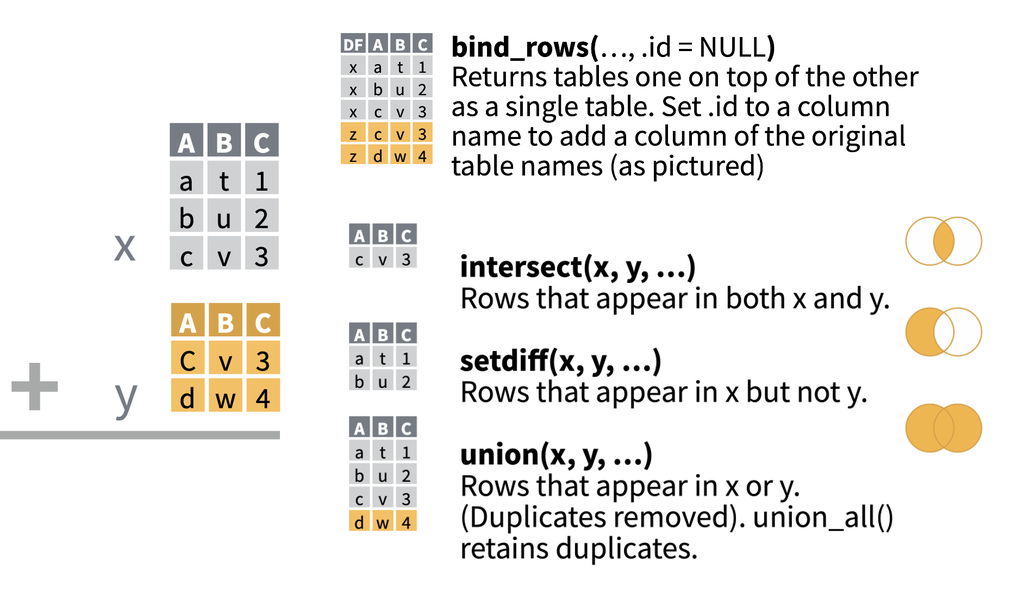

**Figure 13** - Functions useful to combine cases/rows`

```r
# first load the schisto data followed by the hookworm data.

schisto_data_url <- 'https://github.com/WGCAdvancedCourses/Helminths_2021/raw/main/manuals/module_5_R/Schistosoma_mansoni_prevalence_data.txt'
schisto_data <- read_delim(file = schisto_data_url, delim ="\t")

hookworm_data_url <- 'https://github.com/WGCAdvancedCourses/Helminths_2021/raw/main/manuals/module_5_R/Hookworms_prevalence_data.txt'
hookworm_data <- read_delim(file = hookworm_data_url, delim ="\t")

# the argument .id takes a string which each row from individual tibbles
# will be assigned a name into a new "disease" column.
# In this example, the ascaris tibble will be assigned "ascaris" in the "disease"
# column in the new combined.tb tibble
combined.tb <- bind_rows("ascaris" = ascaris_data,"schisto" = schisto_data, .id = "disease")
combined.tb

# you can merge multiple files with the same column format
combined.tb2 <- bind_rows("ascaris" = ascaris_data,"schisto" = schisto_data, "hookroom" = hookworm_data, .id = "disease")
combined.tb2
```

## Part 3: Visusalisation using ggplot2

### Data visualisation `ggplot2`

> “The simple graph has brought more information to the data analyst’s mind than any other device.” — John Tukey

We will go and visualise the data using `ggplot2` that we’ve been wrangling in the previous sections. `ggplot2` is part of the `tidyverse` package which you’ve already loaded this morning.

“R has several systems for making graphs, but ggplot2 is one of the most elegant and most versatile. ggplot2 implements the **grammar of graphics**, a coherent system for describing and building graphs. With ggplot2, you can do more faster by learning one system and applying it in many places.” [R4DS](https://r4ds.had.co.nz/introduction.html)

With ggplot2, you begin a plot with the function `ggplot()`. `ggplot()` creates a coordinate system that you can add layers to. The first argument of `ggplot()` is the dataset to use in the graph. So `ggplot(data = ascaris)` creates an empty graph, but it’s not very interesting so we are not going to show it here.

You complete your graph by adding one or more layers to `ggplot()`. The function `geom_point()` adds a layer of points to your plot, which creates a scatterplot. ggplot2 comes with many geom functions that each add a different type of layer to a plot. We will show a few more examples later.

Let’s look at the `ascaris` tibble in more details, using ggplot to explore. Among the variables we have the number of individuals surveyed (`Individuals_surveyed`) and the number of positive infection cases (`Number_Positives`).

Each geom function in ggplot2 takes a mapping argument. This defines how variables in your dataset are mapped to visual properties. The mapping argument is always paired with `aes()` - the aesthetics - and the x and y arguments of `aes()` specify which variables to map to the x and y axes. ggplot2 looks for the mapped variables in the data argument, in this case, `ascaris`.

To begin to explore the `ascaris` data, run this code to put `Individuals_surveyed` on the x-axis and `Number_Positives` on the y-axis:

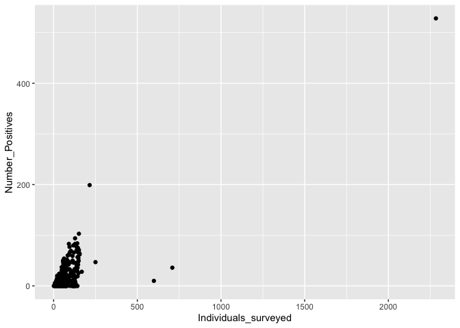

```r
ggplot(ascaris_data) +
  geom_point( aes(x = Individuals_surveyed, y = Number_Positives))
```

The plot shows a positive relationship between `Individuals_surveyed` and `Number_Positives`. In other words, more individuals surveyed also means more cases. Does this confirm or refute our hypothesis about number of individuals and positives?

Let’s turn this code into a reusable template for making graphs with ggplot2. To make a graph, replace the bracketed sections in the code below with a dataset, a geom function, or a collection of mappings.

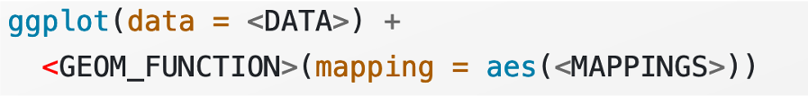

**Figure 14** - A generic usage of ggplot2 from [R4DS](https://r4ds.had.co.nz/introduction.html)`

#### Aesthetic mappings

You can convey information about your data by mapping the aesthetics in your plot to the variables in your dataset. For example, you can map the colors of your points to each variable to reveal the country of each site.

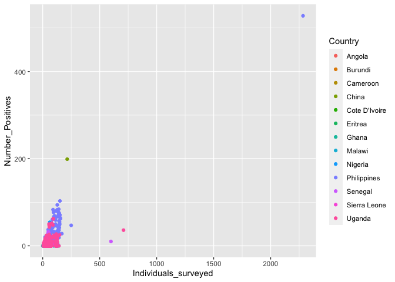

```r
# We note here the different spelling of color and colour are equally okay
ggplot(ascaris_data) +
  geom_point( aes(x = Individuals_surveyed, y = Number_Positives, colour=Country))
```

#### Facets

One way to add additional variables is with aesthetics. Another way, particularly useful for categorical variables, is to split your plot into **facets**, which are subplots that each display one subset of the data.

To facet your plot by a single variable, use `facet_wrap()`. The first argument of `facet_wrap()` should be a formula, which you create with ~ followed by a variable name (here “formula” is the name of a data structure in R, not a synonym for “equation”). The variable that you pass to `facet_wrap()` should be discrete.

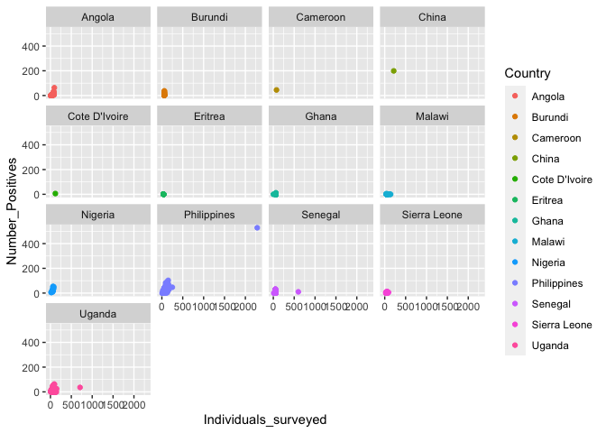

```r
ggplot(ascaris_data) +
  geom_point( aes(x = Individuals_surveyed, y = Number_Positives, colour=Country)) +
  facet_wrap(~ Country, nrow = 4)
```

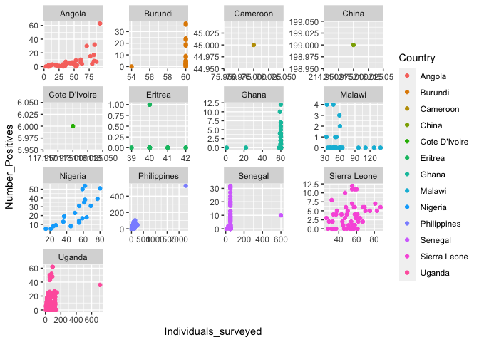

```r
# Note that the axes of each facet are set to be the same - they are "fixed". This can be
# really useful to compare between facets. However, this is not always so useful...

# In this case, having fixed axes is difficult to interpret the data as the number of
# individuals sampled can differ vastly by countries. We can improve this by adding another
# option to make the axes scales "free" or independent per facet plot. Try the following:

ggplot(ascaris_data) +
  geom_point( aes(x = Individuals_surveyed, y = Number_Positives, colour=Country)) +
  facet_wrap(~ Country, nrow = 4, scales="free")
```

#### Boxplot

From the quick scatterplot it seems that there are variations in patterns of parasite prevalence in different countries. Another useful plot would be a boxplot which can be called by the `geom_boxplot()` function. Here we list out the commands that improve the plot bit by bit to generate a polished figure.

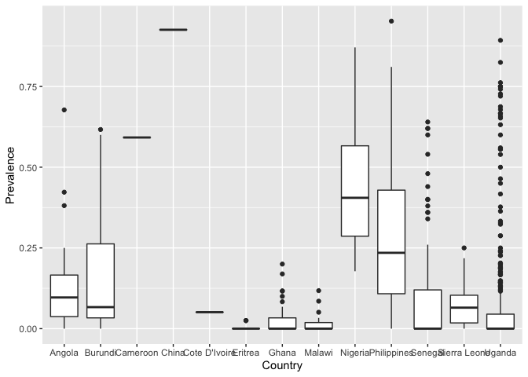

```r
# Let's make a default boxplot and separated by Country
ggplot(ascaris_data) +
  geom_boxplot(aes(x = Country, y = Prevalence))
```

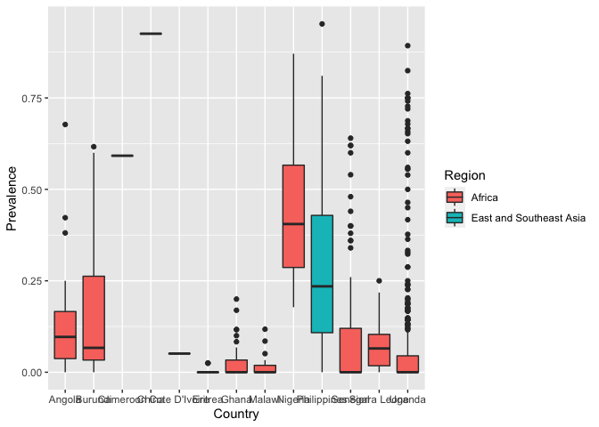

```r
# Colour or "Fill" the boxes with a colour representing each "Region" of the world the
# samples come from.
# Note: you could alternatively the fill the box with colours based by Country, but such
# information is redundant (other than being pretty) because you already have them in x-axis

ggplot(ascaris_data) +
  geom_boxplot(aes(x = Country, y = Prevalence, fill = Region))
```

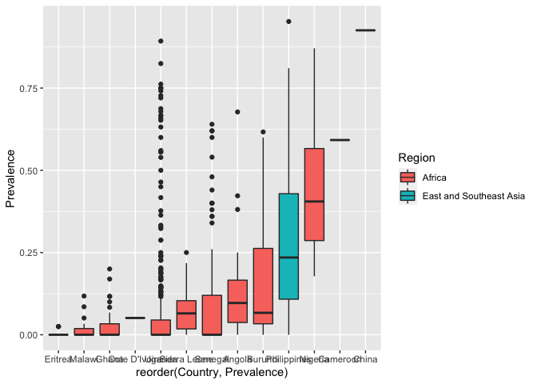

```r
# Reorder the country based on Prevalence
ggplot(ascaris_data) +
  geom_boxplot(aes(x = reorder(Country, Prevalence), y = Prevalence, fill = Region))
```

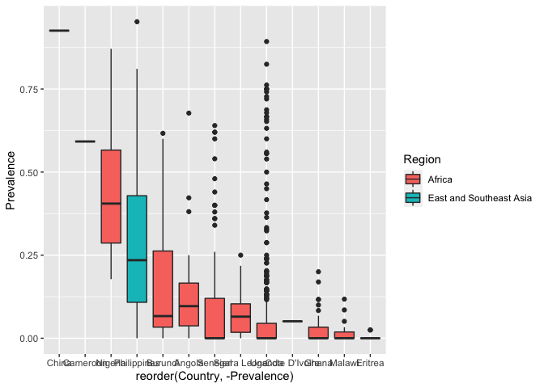

```r
# We are usually interested in which country has the highest prevalence, so let's reorder the
# boxes based on descending order of prevalence
ggplot(ascaris_data) +
  geom_boxplot(aes(x = reorder(Country, -Prevalence), y = Prevalence, fill = Region))
```

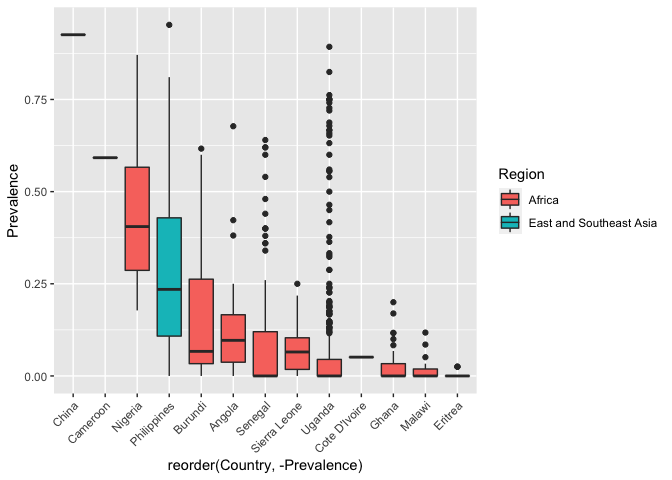

```r
# The previous plot shows the country text at x-axis has overlapped. Let's tilt and adjust accordingly
ggplot(ascaris_data) +
  geom_boxplot(aes(x = reorder(Country, -Prevalence), y = Prevalence, fill = Region)) +
  theme(axis.text.x = element_text(angle = 45, hjust = 1))
```

*Exercises*  
Can you polish the figure further with the following commands?  
1. try writing a different x label. Use `?xlab` command to look in details  
2. or alternatively type `?labs`  
3. try have a different colour pallette of boxplot. *Hint*: `?scale_fill_brewer`